# Text as Data Check-In 4

Author

Maura Anish

Published

November 24, 2024

```r
library(tidyverse)
library(quanteda)
library(quanteda.textplots)
library(quanteda.textmodels)
library(caret)
library(e1071)
library(randomForest)
library(stm)
```

### Research Question and Hypotheses

RQ: According to critics, what makes a good vampire movie? What words are commonly used to describe positively-reviewed vampire movies?

H1: Some words that are used to positively describe any movie (such as “good,” “amazing,” and “fantastic”) will be used to describe well-received vampire movies.

H2: Other words that may not typically describe positive reactions to movies in general (such as “bloody,” “gruesome,” and “disturbing”) may also be used to describe well-received vampire movies.

### Loading and Cleaning Data

On Kaggle (https://www.kaggle.com/datasets/stefanoleone992/rotten-tomatoes-movies-and-critic-reviews-dataset/data), I found a dataset consisting of over 1 million reviews of over 17,000 movies from critics on Rotten Tomatoes. The data was scraped from the Rotten Tomatoes website on October 31, 2020, and thus only contains information about movies released in 2020 or earlier.

```r
# contains all 1,000,000 reviews
all_reviews <- read.csv("C://Users/maura/Documents/DACSS/758/Final/rotten_tomatoes_critic_reviews.csv")
```

After cross-referencing the list of movies reviewed by critics in this dataset with a list of vampire movies, I narrowed down a final list of 154 vampire movie titles contained in the dataset.

```r
# keep 9151 reviews for vampire movies only
vamp_reviews <- filter(all_reviews, rotten_tomatoes_link %in%
                       c("m/fool_there_was", "m/nosferatu", "m/1006234-dracula",
                          "m/vampyr_der_traum_des_allan_grey", "m/vampire_bat",
                          "m/draculas_daughter", "m/the_devil_bat",
                          "m/house_of_frankenstein", "m/the_return_of_the_vampire",
                          "m/house_of_dracula", "m/isle_of_the_dead",
                          "m/abbott_and_costello", "m/1021242-thing",
                          "m/horror_of_dracula", "m/plan-9-from-outer-space",
                          "m/black_sunday", "m/brides_of_dracula",
                          "m/kiss_of_the_vampire_1963",
                          "m/1050388-last_man_on_earth",
                          "m/planet_of_the_vampires", "m/queen_of_blood",
                          "m/the_fearless_vampire_killers",
                          "m/dracula_has_risen_from_the_grave",
                          "m/count_yorga_vampire", "m/house_of_dark_shadows",
                          "m/scars_of_dracula", "m/taste_the_blood_of_dracula",
                          "m/valerie_and_her_week_of_wonders", "m/vampyros_lesbos",
                          "m/lets_scare_jessica_to_death", "m/blacula",
                          "m/dracula_ad_1972", "m/1006235-dracula",
                          "m/ganja_and_hess", "m/scream_blacula_scream",
                          "m/rites_of_dracula", "m/1006236-dracula",
                          "m/nosferatu_the_vampyre", "m/rabid",
                          "m/salems_lot_the_movie", "m/1021262-thirst",
                          "m/the_hunger", "m/1007910-fright_night",
                          "m/once_bitten", "m/vamp", "m/transylvania_6_5000",
                          "m/lifeforce", "m/1014793-near_dark", "m/lost_boys",
                          "m/monster_squad", "m/lair_of_the_white_worm",
                          "m/vampires_kiss", "m/buffy_the_vampire_slayer",
                          "m/innocent_blood", "m/sleepwalkers",
                          "m/interview_with_the_vampire", "m/cronos",
                          "m/dracula_dead_and_loving_it", "m/1068307-addiction",
                          "m/vampire_in_brooklyn", "m/from_dusk_till_dawn",
                          "m/tales_from_the_crypt_presents_bordello_of_blood",
                          "m/habit", "m/1083484-blade",
                          "m/john_carpenters_vampires",
                          "m/from_dusk_till_dawn_2_texas_blood_money",
                          "m/dracula_2000",
                          "m/from_dusk_till_dawn_3_the_hangmans_daughter",
                          "m/immortality", "m/shadow_of_the_vampire",
                          "m/little_vampire", "m/jesus_christ_vampire_hunter",
                          "m/forsaken", "m/blade_ii", "m/queen_of_the_damned",
                          "m/dracula_ii_ascension", "m/underworld",
                          "m/league_of_extraordinary_gentlemen", "m/blade_trinity",
                          "m/van_helsing",
                          "m/wes_craven_presents_dracula_iii_legacy_2004",
                          "m/bloodrayne", "m/10006370-stay_alive",
                          "m/underworld_evolution", "m/30_days_of_night",
                          "m/i_am_legend", "m/10006188-rise",
                          "m/1215969-i_sell_the_dead", "m/let_the_right_one_in",
                          "m/lost_boys_the_tribe", "m/twilight",
                          "m/dead-of-night-2009", "m/10011304-thirst",
                          "m/10011388-blood_the_last_vampire",
                          "m/vampires_assistant", "m/daybreakers",
                          "m/lesbian_vampire_killers", "m/twilight_saga_new_moon",
                          "m/transylmania", "m/underworld_rise_of_the_lycans",
                          "m/let_me_in",
                          "m/rosencrantz_and_guildenstern_are_undead",
                          "m/10011736-suck", "m/1210749-eclipse",
                          "m/vampires_suck", "m/30-days-of-night-dark-days",
                          "m/bit", "m/blood_vessel", "m/embrace_of_the_vampire",
                          "m/eulogy_for_a_vampire",
                          "m/lemora_a_childs_tale_of_the_supernatural",
                          "m/lost_boys_the_thirst_2010", "m/my_sucky_teen_romance",
                          "m/subspecies", "m/the_night_watchmen",
                          "m/vampires_seduction", "m/vampires_los_muertos",
                          "m/fright_night_2011", "m/10009274-priest",
                          "m/stake_land",
                          "m/the_twilight_saga_breaking_dawn_part_1",
                          "m/abraham_lincoln_vampire_hunter",
                          "m/dark-shadows-2010", "m/hotel_transylvania",
                          "m/the_twilight_saga_breaking_dawn_part_2",
                          "m/underworld_awakening", "m/we_are_the_night",
                          "m/vamps_2011", "m/byzantium_2012", "m/chastity_bites",
                          "m/kiss_of_the_damned_2012", "m/the_moth_diaries",
                          "m/the_mortal_instruments_city_of_bones",
                          "m/the_abcs_of_death",
                          "m/a_girl_walks_home_alone_at_night",
                          "m/blood_ransom", "m/dracula_untold",
                          "m/only_lovers_left_alive", "m/rigor_mortis_2013",
                          "m/vampire_academy", "m/bloodsucking_bastards",
                          "m/da_sweet_blood_of_jesus", "m/hotel_transylvania_2",
                          "m/what_we_do_in_the_shadows", "m/yakuza_apocalypse",
                          "m/the_monster_project", "m/underworld_blood_wars_2017",
                          "m/hotel_transylvania_3_summer_vacation",
                          "m/living_among_us", "m/monster_family", "m/bliss_2019",
                          "m/rabid_2019", "m/the_shed_2019",
                          "m/scoobydoo_and_the_reluctant_werewolf")
                       )
rm(all_reviews)
write.csv(vamp_reviews, "vamp_reviews.csv")
```

By only retaining the reviews of vampire movies, I narrowed down the number of reviews from over 1 million to just over 9,000.

```r
# read in dataset with only vampire movie reviews
vamp_reviews <- read.csv("C://Users/maura/Documents/DACSS/758/Final/vamp_reviews.csv")
vamp_reviews <- vamp_reviews |>
  rename(movie_ID = rotten_tomatoes_link) |>
  rename(review_freshness = review_type) |>
  select(movie_ID, critic_name, publisher_name, review_freshness, review_date, review_content) |>
  mutate(review_date = mdy(review_date)) |>
  arrange(review_date)
dim(vamp_reviews)
```

```
[1] 9151    6
```

```r
head(vamp_reviews)
```

```
                      movie_ID        critic_name       publisher_name
1    m/plan-9-from-outer-space     Jennie Kermode         Eye for Film
2             m/innocent_blood                    Entertainment Weekly
3 m/interview_with_the_vampire                    Entertainment Weekly
4              m/1083484-blade         Scott Nash    Three Movie Buffs
5   m/john_carpenters_vampires                    Entertainment Weekly
6            m/1006234-dracula James Berardinelli            ReelViews
  review_freshness review_date
1           Rotten  1959-07-02
2           Rotten  1992-09-25
3           Rotten  1994-11-11
4            Fresh  1998-08-21
5           Rotten  1998-10-30
6            Fresh  2000-01-01
                                                                                                      review_content
1
2
3
4                                                               It's stylish and fast-paced. It's also a lot of fun.
5
6 Dracula deserves its status as a classic, although one might be tempted to append the word 'lesser' to that label.
```

The number of reviews of vampire movies was further reduced after removing reviews from critics that only contained a rating with no additional text, reviews that appeared in the dataset more than once, and reviews that weren’t in English.

```r
# remove rows with no review
vamp_reviews <- filter(vamp_reviews, str_length(review_content)>1)
dim(vamp_reviews)
```

```
[1] 8636    6
```

```r
# remove duplicate rows
vamp_reviews <- distinct(vamp_reviews)
dim(vamp_reviews)
```

```
[1] 8306    6
```

```r
# remove reviews that aren't in english
vamp_reviews <- vamp_reviews |>
  filter(publisher_name != "Cinema em Cena" &
           publisher_name != "Cinenganos" &
           publisher_name != "EnPrimeur.ca" &
           publisher_name != "Movies for the Masses" &
           publisher_name != "Moviola" &
           publisher_name != "Panorama" &
           publisher_name != "Uruguay Total")
dim(vamp_reviews)
```

```
[1] 8254    6
```

### Exploratory Data Analysis

After the reviews had been cleaned, I split them into two subsets: one consisting only of “Fresh” reviews (if the critic liked the movie), and one consisting only of “Rotten” reviews (if the critic didn’t like the movie). There was an almost equal number of Fresh (4,181) and Rotten (4,073) reviews.

```r
# create fresh and rotten datasets
fresh_reviews <- filter(vamp_reviews, review_freshness == "Fresh")
dim(fresh_reviews)
```

```
[1] 4181    6
```

```r
rotten_reviews <- filter(vamp_reviews, review_freshness == "Rotten")
dim(rotten_reviews)
```

```
[1] 4073    6
```

```r
# create fresh corpus
fresh_reviews$review_ID <- str_c("F", seq(1:nrow(fresh_reviews)))
fresh_corpus <- corpus(fresh_reviews, docid_field = "review_ID",
                       text_field = "review_content")
summary(fresh_corpus, n=10)
```

```
Corpus consisting of 4181 documents, showing 10 documents:

 Text Types Tokens Sentences               movie_ID         critic_name
   F1    10     12         2        m/1083484-blade          Scott Nash
   F2    22     24         1      m/1006234-dracula  James Berardinelli
   F3    22     30         3      m/1006234-dracula Jeffrey M. Anderson
   F4    24     24         1      m/1006234-dracula           Tim Dirks
   F5     3      3         1      m/1006234-dracula    MaryAnn Johanson
   F6    23     24         1      m/1006234-dracula         Roger Ebert
   F7    17     18         1 m/1007910-fright_night         Roger Ebert
   F8     6      6         1    m/1014793-near_dark    Christopher Null
   F9     5      5         1    m/1014793-near_dark      Shane Burridge
  F10    34     40         1    m/1014793-near_dark          Hal Hinson
          publisher_name review_freshness review_date
       Three Movie Buffs            Fresh  1998-08-21
               ReelViews            Fresh  2000-01-01
   Combustible Celluloid            Fresh  2000-01-01
            AMC Filmsite            Fresh  2000-01-01
        Flick Filosopher            Fresh  2000-01-01
       Chicago Sun-Times            Fresh  2000-01-01
       Chicago Sun-Times            Fresh  2000-01-01
          Filmcritic.com            Fresh  2000-01-01
 rec.arts.movies.reviews            Fresh  2000-01-01
         Washington Post            Fresh  2000-01-01
```

```r
# create rotten corpus
rotten_reviews$review_ID <- str_c("R", seq(1:nrow(rotten_reviews)))
rotten_corpus <- corpus(rotten_reviews, docid_field = "review_ID",
                       text_field = "review_content")
summary(rotten_corpus, n=10)
```

```
Corpus consisting of 4073 documents, showing 10 documents:

 Text Types Tokens Sentences            movie_ID       critic_name
   R1    12     14         1 m/1014793-near_dark    Mark R. Leeper
   R2    18     18         1     m/1021242-thing     James O'Ehley
   R3    14     17         1 m/1068307-addiction        Hal Hinson
   R4    26     31         1 m/1068307-addiction Walter V. Addiego
   R5    19     19         1 m/1068307-addiction       Chris Hicks
   R6    10     10         1 m/1068307-addiction   Dennis Schwartz
   R7    18     18         1     m/1083484-blade      Elias Savada
   R8    18     20         1     m/1083484-blade          Tom Long
   R9    19     19         1     m/1083484-blade   Rob Blackwelder
  R10    11     11         1     m/1083484-blade     Scott Renshaw
                publisher_name review_freshness review_date
       rec.arts.movies.reviews           Rotten  2000-01-01
             Sci-Fi Movie Page           Rotten  2000-01-01
               Washington Post           Rotten  2000-01-01
        San Francisco Examiner           Rotten  2000-01-01
 Deseret News (Salt Lake City)           Rotten  2000-01-01
 Dennis Schwartz Movie Reviews           Rotten  2000-01-01
                Nitrate Online           Rotten  2000-01-01
                  Detroit News           Rotten  2000-01-01
                   SPLICEDWire           Rotten  2000-01-01
       rec.arts.movies.reviews           Rotten  2000-01-01
```

#### Word Clouds

Next, I wanted to get a sense of which words were most frequently used in both corpora.

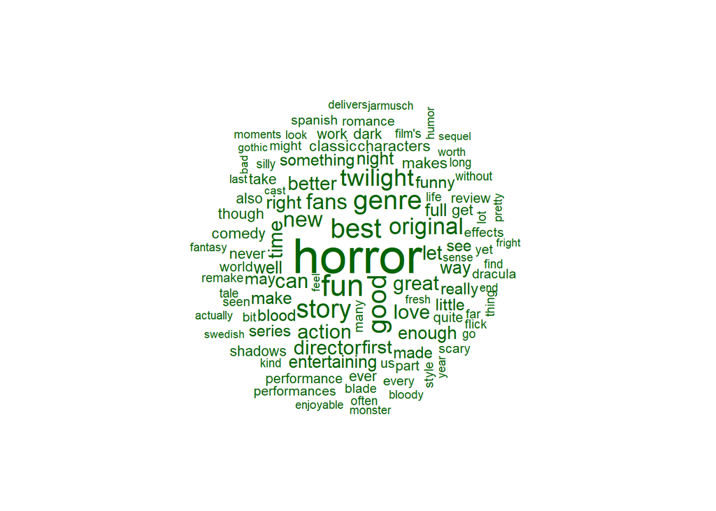

```r
# tokenize; remove punctuation, numbers, and stopwords
fresh_tokens <- tokens(fresh_corpus,
                       remove_punct = T, remove_numbers = T) |>
  tokens_select(pattern=c("film", "films", "movie", "movies",
                          "vampire", "vampires", "one", "two",
                          "like", "just", "still", "much", "even"),
                select = "remove")

# make document feature matrix
fresh_dfm <- dfm(fresh_tokens) |>
  dfm_remove(stopwords('english')) |>
  dfm_trim(min_termfreq = 50, verbose = FALSE)

# make word cloud
set.seed(12)
textplot_wordcloud(fresh_dfm, color="darkgreen")
```

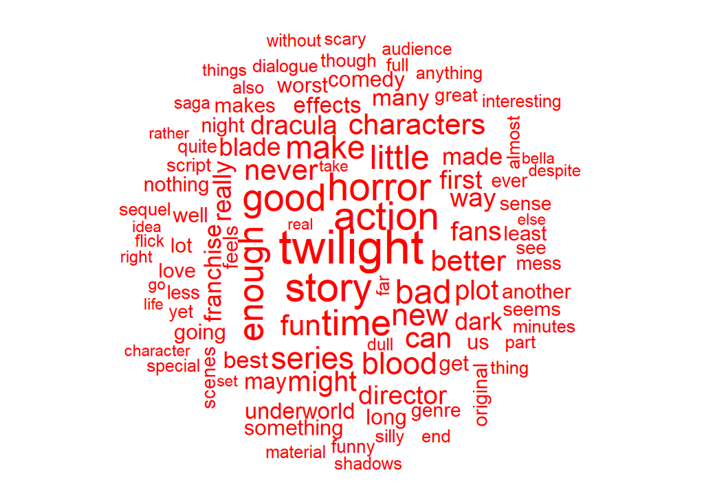

```r
# tokenize; remove punctuation, numbers, and stopwords
rotten_tokens <- tokens(rotten_corpus,
                       remove_punct = T, remove_numbers = T) |>
  tokens_select(pattern=c("film", "films", "movie", "movies",
                          "vampire", "vampires", "one", "two",
                          "like", "just", "still", "much", "even"),
                select = "remove")

# make document feature matrix
rotten_dfm <- dfm(rotten_tokens) |>
  dfm_remove(stopwords('english')) |>
  dfm_trim(min_termfreq = 50, verbose = FALSE)

# make word cloud
set.seed(12)
textplot_wordcloud(rotten_dfm, color="red")
```

The word clouds for the positive and negatively reviewed vampire movies have some overlap, but they also have their differences. The Fresh word cloud has words like “good,” “great,” “best,” “fun,” “original,” “love,” and “entertaining,” which are expected to be associated with positive reviews. The Rotten word cloud has words like “bad,” “enough,” “little,” “never,” “worst,” “nothing,” and “mess,” which are expected to be associated with negative reviews. However, the Rotten word cloud also contains the common positive words like “good,” “great,” “best,” “fun,” “original,” and “love,” which might be frequently negated in the negative reviews, but that isn’t captured by the unigram analysis performed here.

Both word clouds also contain some words related to specific movies, such as “Twilight,” “Underworld,” “Dracula,” “Blade,” and “Bella.” It’s not surprising that the vampire movie franchises with multiple entries like *Twilight* (5 films), *Underworld* (5 films), and *Blade* (3 films) are discussed more than films which stand alone. The character of Dracula is also featured in many different vampire movies, and even if he isn’t explicitly present in them, he presents a well-known figure for critics to compare the depictions of other vampires to in their reviews. Other vampire-specific words in the clouds include “horror,” “action,” “blood,” “dark,” “shadows,” “gothic,” and “scary.”

Finally, both word clouds feature words pertaining to aspects of the movies that critics discuss. These words include “story,” “plot,” “characters,” “genre,” “effects,” “script,” “director,” and “performance.” Going forward, it could be helpful to study how these elements of the movies are discussed (such as which adjectives frequently accompany them) to distinguish positive from negative reviews. A similar tactic could also be applied to the adjectives used near common words like “film,” “movie,” or “vampire.”

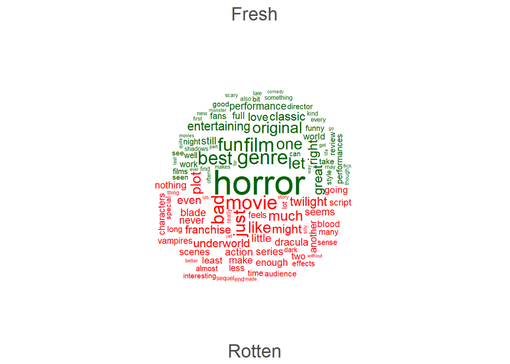

```r
# make a corpus with 2 documents (1 for all fresh and 1 for all rotten reviews)
fresh_review_text <- paste(fresh_reviews$review_content, collapse=" ")
rotten_review_text <- paste(rotten_reviews$review_content, collapse=" ")
fr_df <- tibble(freshness = c("Fresh", "Rotten"),
                review_text = c(fresh_review_text, rotten_review_text))
fr_corpus <- corpus(fr_df, docid_field = "freshness", text_field = "review_text")

# tokenize; remove punctuation, numbers, and stopwords
fr_tokens <- tokens(fr_corpus, remove_punct = T, remove_numbers = T) |>
  tokens_select(pattern="vampire", select = "remove")

# make document feature matrix
fr_dfm <- dfm(fr_tokens) |> dfm_remove(stopwords('english')) |>
  dfm_trim(min_termfreq = 100, verbose = FALSE)

# make comparison word cloud
set.seed(15)
textplot_wordcloud(fr_dfm, comparison = TRUE, color = c("darkgreen", "red"))
```

The comparison word cloud highlights many of the differences that are observable from the separate word clouds above. However, this word cloud makes it clear that the Fresh reviews are more likely to contain positive words like “great,” “best,” “original,” “fun,” “entertaining,” and “classic” than Rotten reviews are. Rotten reviews are more likely to contain negative words like “bad” and “nothing” along with words about largely negatively-received series such as “Twilight,” “Underworld,” “Blade,” and the word “franchise” in general.

#### Co-Occurrence Networks

I was curious to see if the ways in which critics described vampires in their reviews would be indicative of their feelings about the movies. In order to do so, I created co-occurrence networks to examine the 30 most frequent words that were 5 words or fewer away from the words “vampire” or “vampires.”

```r
# tokenize corpora; remove punctuation, numbers, and stopwords
fresh_tokens <- tokens(fresh_corpus, remove_punct = T, remove_numbers = T) |>
  tokens_select(pattern = stopwords(), select = "remove") |> tokens_tolower()
rotten_tokens <- tokens(rotten_corpus, remove_punct = T, remove_numbers = T) |>
  tokens_select(pattern = stopwords(), select = "remove") |> tokens_tolower()
```

```r
# keep words surrounding "vampire" or "vampires" in reviews
fresh_near_vamp <- tokens_select(fresh_tokens, pattern = "vampire",
                                 window = 5, selection = "keep")
fresh_near_vamps <- tokens_select(fresh_tokens, pattern = "vampires",
                                  window = 5, selection = "keep")
rotten_near_vamp <- tokens_select(rotten_tokens, pattern = "vampire",
                                  window = 5, selection = "keep")
rotten_near_vamps <- tokens_select(rotten_tokens, pattern = "vampires",
                                   window = 5, selection = "keep")

# create feature co-occurrence matrices
fresh_fcm1 <- fcm(fresh_near_vamp, context = "window")
fresh_fcm2 <- fcm(fresh_near_vamps, context = "window")
rotten_fcm1 <- fcm(rotten_near_vamp, context = "window")
rotten_fcm2 <- fcm(rotten_near_vamps, context = "window")

# only keep 30 most frequent co-occurring words
top_fresh_feats1 <- names(sort(colSums(fresh_fcm1), decreasing = TRUE)[1:30])
vamp_fresh_fcm <- fcm_select(fresh_fcm1, pattern = c("vampire", top_fresh_feats1))
top_fresh_feats2 <- names(sort(colSums(fresh_fcm2), decreasing = TRUE)[1:30])
vamps_fresh_fcm <- fcm_select(fresh_fcm2, pattern = c("vampires", top_fresh_feats2))
top_rot_feats1 <- names(sort(colSums(rotten_fcm1), decreasing = TRUE)[1:30])
vamp_rot_fcm <- fcm_select(rotten_fcm1, pattern = c("vampire", top_rot_feats1))
top_rot_feats2 <- names(sort(colSums(rotten_fcm2), decreasing = TRUE)[1:30])
vamps_rot_fcm <- fcm_select(rotten_fcm2, pattern = c("vampires", top_rot_feats2))
```

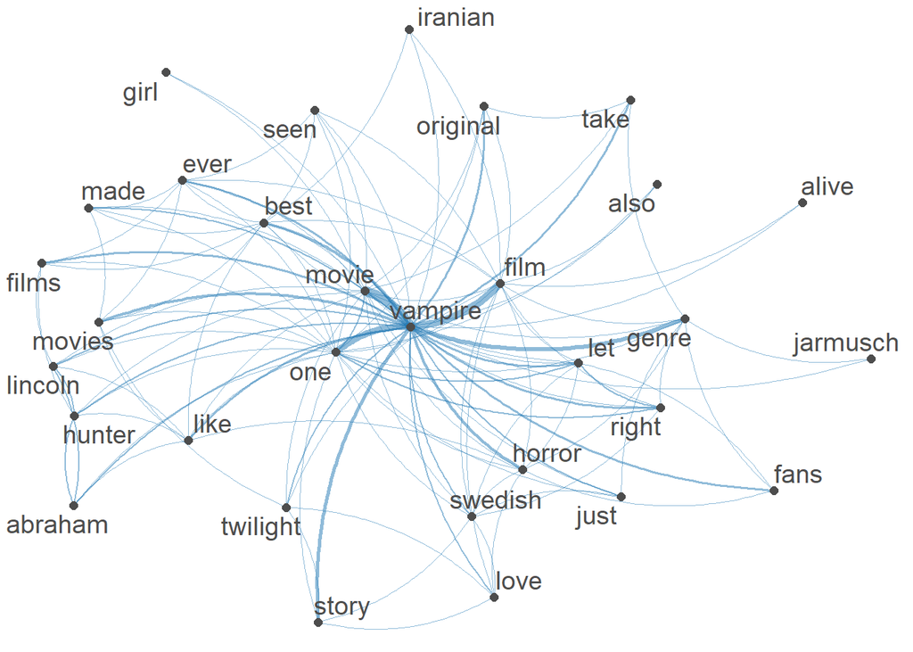

```r
set.seed(12)
textplot_network(vamp_fresh_fcm)
```

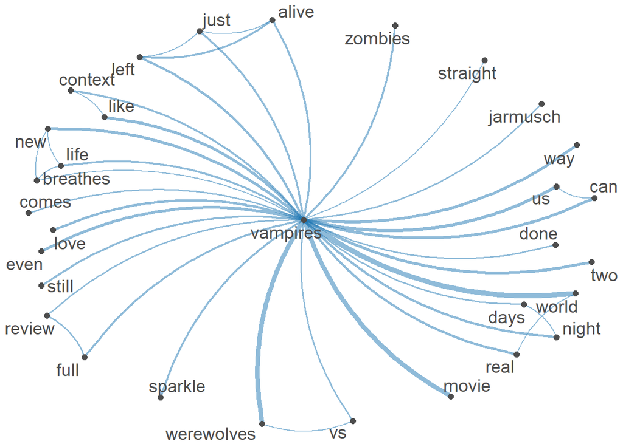

```r
set.seed(12)
textplot_network(vamps_fresh_fcm)
```

The co-occurrence networks of “vampire” and “vampires” for Fresh reviews include some positive words such as “original,” “love,” “best,” and “new.” There are also some words like “Iranian,” “Swedish,” “Abraham,” “Lincoln,” “Twilight,” and “Jarmusch” which are specific to certain movies.

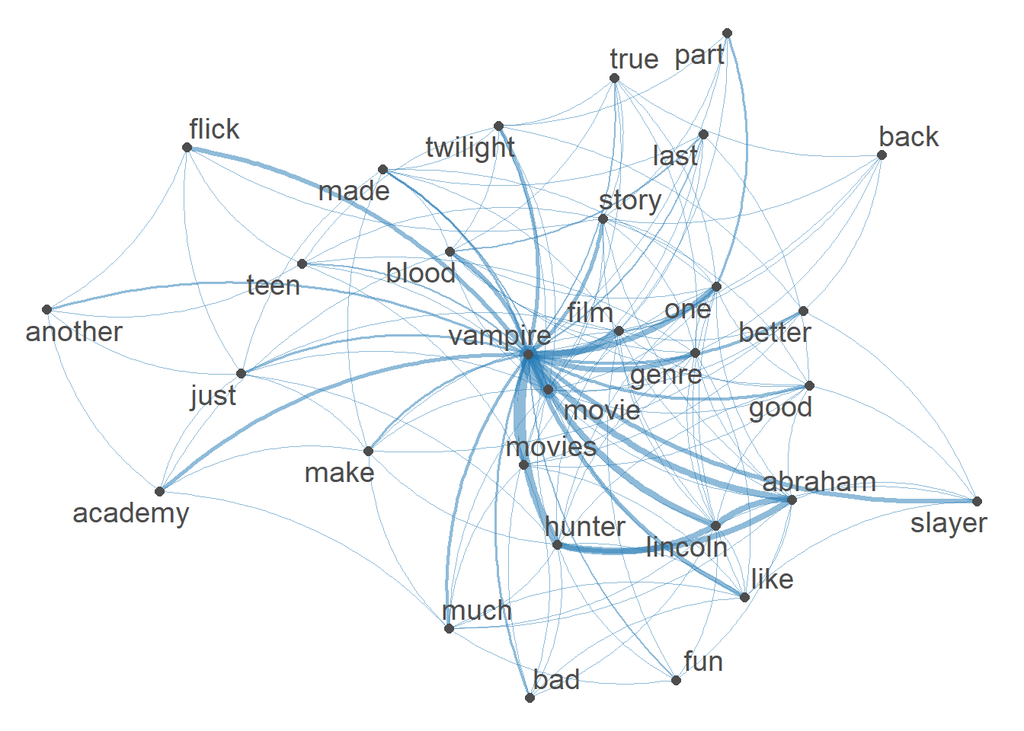

```r
set.seed(12)
textplot_network(vamp_rot_fcm)
```

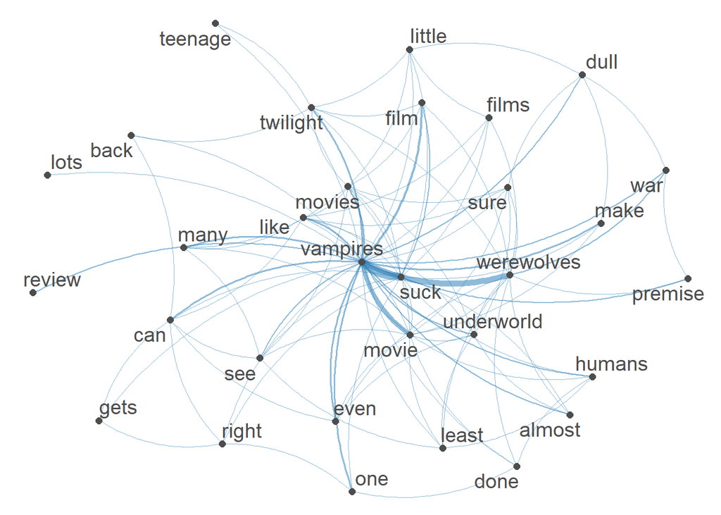

```r
set.seed(12)
textplot_network(vamps_rot_fcm)
```

The co-occurrence networks of “vampire” and “vampires” for Rotten reviews include some negative words like “bad,” “dull,” and “suck,” but they also feature some positive words like “good,” “better,” “fun,” and “right.” Similarly to the co-occurrence networks for the positive reviews, there are some movie-specific words such as “Abraham,” “Lincoln,” “Academy,” “Twilight,” and “Underworld.”

### Supervised Learning

With a basic understanding of some of the most common words used in positive and negative reviews of vampire movies, I proceeded to apply supervised learning techniques to the data. My goal was to see how well these algorithms could predict the sentiment of the reviews and which words in the reviews were most strongly used to signal the sentiment.

```r
# make one big corpus
vamp_reviews$review_ID <- seq(1:nrow(vamp_reviews))
vamp_corpus <- corpus(vamp_reviews, docid_field = "review_ID",
                      text_field = "review_content")
docvars(vamp_corpus, "review_ID") <- vamp_reviews$review_ID
ndoc(vamp_corpus)
```

```
[1] 8254
```

```r
# set seed, then split into training and testing sets
set.seed(12)
N <- ndoc(vamp_corpus)
trainIndex <- sample(1:N, .8*N)
testIndex <- c(1:N)[-trainIndex]

# create dfms for different subsets
dfmTrain <- corpus_subset(vamp_corpus, review_ID %in% trainIndex) |>
  tokens() |> dfm() |> dfm_trim(min_docfreq = 20)
dim(dfmTrain) # 80% of all documents
```

```
[1] 6603  856
```

```r
dfmTest <- corpus_subset(vamp_corpus, review_ID %in% testIndex) |>
  tokens() |> dfm()
dim(dfmTest) # 20% of all documents
```

```
[1] 1651 6759
```

#### Naive Bayes Model

```r
# run Naive Bayes model on the training data
nb_model <- textmodel_nb(dfmTrain, docvars(dfmTrain, "review_freshness"),
                         distribution = "Bernoulli")
summary(nb_model)
```

```
Call:
textmodel_nb.dfm(x = dfmTrain, y = docvars(dfmTrain, "review_freshness"),
    distribution = "Bernoulli")

Class Priors:
(showing first 2 elements)
 Fresh Rotten
   0.5    0.5

Estimated Feature Scores:
         it's  stylish    and      .    also      a     lot     of     fun
Fresh  0.1333 0.010164 0.5291 0.9477 0.01854 0.5456 0.01495 0.4682 0.05710
Rotten 0.1245 0.004292 0.4338 0.9519 0.01502 0.4957 0.01931 0.4555 0.02728
       dracula deserves     its     as  classic      , although     one   might
Fresh  0.01614 0.005381 0.11928 0.1229 0.021824 0.6652 0.007175 0.10374 0.01824
Rotten 0.02422 0.002146 0.09749 0.1309 0.007357 0.6235 0.003372 0.07879 0.02698
            be     to    the       '   that   lugosi     is     in     role
Fresh  0.09238 0.3265 0.6389 0.04514 0.2033 0.004783 0.3300 0.2828 0.006278
Rotten 0.10362 0.3657 0.6272 0.04936 0.2115 0.001839 0.3185 0.2373 0.005825
       vampire     can      no
Fresh  0.13871 0.03259 0.02960
Rotten 0.08185 0.02820 0.04568
```

```r
# evaluate performance of model on test data
dfmTestMatched <- dfm_match(dfmTest, features = featnames(dfmTrain))
actual <- docvars(dfmTestMatched, "review_freshness")
predicted <- predict(nb_model, newdata = dfmTestMatched)
confusion <- table(predicted, actual)
confusionMatrix(confusion)
```

```
Confusion Matrix and Statistics

         actual
predicted Fresh Rotten
   Fresh    564    196
   Rotten   274    617

               Accuracy : 0.7153
                 95% CI : (0.6929, 0.737)
    No Information Rate : 0.5076
    P-Value [Acc > NIR] : < 2.2e-16

                  Kappa : 0.4313

 Mcnemar's Test P-Value : 0.0003827

            Sensitivity : 0.6730
            Specificity : 0.7589
         Pos Pred Value : 0.7421
         Neg Pred Value : 0.6925
             Prevalence : 0.5076
         Detection Rate : 0.3416
   Detection Prevalence : 0.4603
      Balanced Accuracy : 0.7160

       'Positive' Class : Fresh
```

From these initial results, we can see that the Naive Bayes model performed fairly well, with an accuracy of 72%. This is significantly better than classifying all reviews are positive, indicated by the 21% increase from the No Information Rate of 51%.

```r
# compare probabilities of features belonging to positive or negative reviews
nb_feature_probs <- as.data.frame(t(nb_model$param))
nb_feature_probs$Difference <- nb_feature_probs$Fresh - nb_feature_probs$Rotten
```

```r
# examine words that are more positive than negative
head(arrange(nb_feature_probs, desc(Difference)))
```

```
             Fresh     Rotten Difference
and     0.52914798 0.43378296 0.09536503
vampire 0.13871450 0.08185162 0.05686287
horror  0.09745889 0.04199877 0.05546012
a       0.54559043 0.49570815 0.04988228
in      0.28281016 0.23727774 0.04553242
,       0.66517190 0.62354384 0.04162806
```

```r
# examine words that are more negative than positive
head(arrange(nb_feature_probs, Difference))
```

```
         Fresh     Rotten  Difference
to  0.32645740 0.36572655 -0.03926915
:   0.03886398 0.06345800 -0.02459403
so  0.04364723 0.06529736 -0.02165013
or  0.04334828 0.06499080 -0.02164252
not 0.08579970 0.10668302 -0.02088332
bad 0.01106129 0.02881668 -0.01775539
```

Many of the words that are shown to be the “most positive” or the “most negative,” based on the difference in the probability they belong to positive or negative reviews, are stopwords or punctuation. In addition to traditional stopwords like “and,” “a,” “in,” “to,” “so,” and “or,” “vampire” can also be considered a stopword in the context of this corpus. It is interesting that “horror” tends to be used more often in positive reviews, though, while it makes sense for “not” and “bad” to be used more often in negative reviews.

Given these initial results, I wanted to re-run the Naive Bayes model without including stopwords or punctuation in the document-feature matrices, to see how that would affect the results.

```r
# create dfms without stopwords or punctuation
dfmTrain <- corpus_subset(vamp_corpus, review_ID %in% trainIndex) |>
  tokens(remove_punct=T) |> tokens_select(c("vampire", "vampires"), selection="remove") |>
  dfm() |> dfm_remove(stopwords('english')) |> dfm_trim(min_docfreq = 20)
dim(dfmTrain) # 80% of all documents
```

```
[1] 6603  711
```

```r
dfmTest <- corpus_subset(vamp_corpus, review_ID %in% testIndex) |>
  tokens(remove_punct=T) |> tokens_select(c("vampire", "vampires"), selection="remove") |>
  dfm() |> dfm_remove(stopwords('english'))
dim(dfmTest) # 20% of all documents
```

```
[1] 1651 6581
```

```r
# run NB model with no stop words
nb_model_nsw <- textmodel_nb(dfmTrain, docvars(dfmTrain, "review_freshness"),
                          distribution = "Bernoulli")
summary(nb_model_nsw)
```

```
Call:
textmodel_nb.dfm(x = dfmTrain, y = docvars(dfmTrain, "review_freshness"),
    distribution = "Bernoulli")

Class Priors:
(showing first 2 elements)
 Fresh Rotten
   0.5    0.5

Estimated Feature Scores:
        stylish    also     lot     fun dracula deserves  classic although
Fresh  0.010164 0.01854 0.01495 0.05710 0.01614 0.005381 0.021824 0.007175
Rotten 0.004292 0.01502 0.01931 0.02728 0.02422 0.002146 0.007357 0.003372
           one   might   lugosi     role     can    good performance     bad
Fresh  0.10374 0.01824 0.004783 0.006278 0.03259 0.04484    0.016741 0.01106
Rotten 0.07879 0.02698 0.001839 0.005825 0.02820 0.03832    0.006744 0.02882
       american  horror   films universal directed   fright   night  movie
Fresh  0.007773 0.09746 0.03558  0.004484 0.007175 0.011659 0.02750 0.1088
Rotten 0.003679 0.04200 0.02667  0.003679 0.004905 0.008584 0.01931 0.1235
         scenes    long  violent   bloody   boring definitely
Fresh  0.008072 0.01465 0.003288 0.014051 0.001495   0.006876
Rotten 0.018087 0.02054 0.003679 0.007664 0.011343   0.004292
```

```r
# evaluate performance of new model on test data
dfmTestMatched <- dfm_match(dfmTest, features = featnames(dfmTrain))
actual <- docvars(dfmTestMatched, "review_freshness")
predicted <- predict(nb_model_nsw, newdata = dfmTestMatched)
confusion <- table(predicted, actual)
confusionMatrix(confusion)
```

```
Confusion Matrix and Statistics

         actual
predicted Fresh Rotten
   Fresh    536    198
   Rotten   302    615

               Accuracy : 0.6972
                 95% CI : (0.6743, 0.7193)
    No Information Rate : 0.5076
    P-Value [Acc > NIR] : < 2.2e-16

                  Kappa : 0.3953

 Mcnemar's Test P-Value : 4.099e-06

            Sensitivity : 0.6396
            Specificity : 0.7565
         Pos Pred Value : 0.7302
         Neg Pred Value : 0.6707
             Prevalence : 0.5076
         Detection Rate : 0.3247
   Detection Prevalence : 0.4446
      Balanced Accuracy : 0.6980

       'Positive' Class : Fresh
```

```r
# compare probabilities of features
nb_feature_probs <- as.data.frame(t(nb_model_nsw$param))
nb_feature_probs$Difference <- nb_feature_probs$Fresh - nb_feature_probs$Rotten
```

```r
# examine words that are more positive than negative
head(arrange(nb_feature_probs, desc(Difference)))
```

```
            Fresh     Rotten Difference
horror 0.09745889 0.04199877 0.05546012
film   0.15784753 0.12385040 0.03399714
fun    0.05710015 0.02728387 0.02981627
best   0.04962631 0.02023299 0.02939332
genre  0.04603886 0.01778050 0.02825836
one    0.10373692 0.07878602 0.02495090
```

```r
# examine words that are more negative than positive
head(arrange(nb_feature_probs, Difference))
```

```
            Fresh     Rotten  Difference
bad   0.011061286 0.02881668 -0.01775539
worst 0.003288490 0.02053955 -0.01725106
like  0.056502242 0.07234825 -0.01584601
mess  0.002092676 0.01778050 -0.01568783
movie 0.108819133 0.12354384 -0.01472471
just  0.045739910 0.05977928 -0.01403937
```

Removing the stopwords and punctuation from the DFMs resulted in a slightly lower classification accuracy of around 70%. This time, the most positive and most negative words make more sense, however. Words like “fun” and “best” are more likely to appear in positive reviews, while words like “bad,” “worst,” and “mess” are more likely to appear in negative reviews. It’s also interesting to note that positive reviews are more likely to refer to their objects of critique as “films,” while negative reviews refer to them as “movies,” which doesn’t imply as high of an artistic value as the word “film” does.

#### Support Vector Machines

```r
# use same DFM used for NB model (trimmed, doesn't contain punctuation or stopwords)
dim(dfmTrain)
```

```
[1] 6603  711
```

```r
# run SVM model
svm_model <- textmodel_svm(dfmTrain, docvars(dfmTrain, "review_freshness"))
```

```r
# evaluate performance of model on test data
dfmTestMatched <- dfm_match(dfmTest, features = featnames(dfmTrain))
actual <- docvars(dfmTestMatched, "review_freshness")
predicted <- predict(svm_model, newdata = dfmTestMatched)
confusion <- table(predicted, actual)
confusionMatrix(confusion)
```

```
Confusion Matrix and Statistics

         actual
predicted Fresh Rotten
   Fresh    537    237
   Rotten   301    576

               Accuracy : 0.6741
                 95% CI : (0.6509, 0.6967)
    No Information Rate : 0.5076
    P-Value [Acc > NIR] : < 2.2e-16

                  Kappa : 0.3489

 Mcnemar's Test P-Value : 0.006605

            Sensitivity : 0.6408
            Specificity : 0.7085
         Pos Pred Value : 0.6938
         Neg Pred Value : 0.6568
             Prevalence : 0.5076
         Detection Rate : 0.3253
   Detection Prevalence : 0.4688
      Balanced Accuracy : 0.6746

       'Positive' Class : Fresh
```

With an accuracy around 67%, the SVM model performed slightly worse than the Naive Bayes model, but not by much.

```r
# examine most positive and most negative features
svmCoefs <- as.data.frame(t(coefficients(svm_model)))
svmCoefs <- svmCoefs |> arrange(V1)
tail(svmCoefs, 20)
```

```
                    V1
delight      0.6781327
terrific     0.6944548
atmospheric  0.6990528
jarmusch     0.7337710
brilliant    0.7406227
delivers     0.7568823
debut        0.7618587
haunting     0.7931365
nosferatu    0.7932724
humour       0.7935092
eerie        0.8180130
enjoyable    0.8268103
succeeds     0.8765090
rare         0.8942442
perfectly    0.9276156
amirpour     0.9611372
greatest     0.9718226
walks        1.0029061
jarmusch's   1.0571220
mockumentary 1.8631533
```

```r
head(svmCoefs, 20)
```

```
                    V1
bland       -1.0052580
bloodless   -0.9465623
tedious     -0.9401503
neither     -0.9036949
dull        -0.8842920
poor        -0.8616330
boring      -0.8408063
stupid      -0.8217109
needs       -0.8081771
opportunity -0.7839582
mess        -0.7631253
worst       -0.7200534
flat        -0.7171084
hardly      -0.7042081
priest      -0.6930285
attempt     -0.6888932
tries       -0.6864349
bones       -0.6435239
predictable -0.6347164
utterly     -0.6257821
```

The top 20 most positive and top 20 most negative features from the SVM model make intuitive sense. Some of the most positive features include “delight,” “terrific,” “brilliant,” “enjoyable,” “succeeds,” and “greatest.” Some of the most negative features include “bland,” “tedious,” “neither,” “dull,” “poor,” and “stupid.” There are also certain words, like “Amirpour,” “Jarmusch,” and “Nosferatu,” which are included in the top 20 positive features because of the creators or characters of specific highly-rated films and are not applicable to vampire movies as a whole.

#### Random Forests

```r
# convert DFMs to matrices to run random forest model
dfmTrainMatrix <- convert(dfmTrain, to = "matrix")
dim(dfmTrainMatrix)
```

```
[1] 6603  711
```

```r
dfmTestMatchedMatrix <- convert(dfmTestMatched, to = "matrix")
dim(dfmTestMatchedMatrix)
```

```
[1] 1651  711
```

```r
# build RF model using 25 features per tree and 100 trees
rf_model <- randomForest(dfmTrainMatrix,
                         y = as.factor(docvars(dfmTrain)$review_freshness),
                         xtest = dfmTestMatchedMatrix,
                         ytest = as.factor(docvars(dfmTestMatched)$review_freshness),
                         importance = TRUE, mtry = 25, ntree = 100)
```

```r
# evaluate model on test data
actual <- as.factor(docvars(dfmTestMatched)$review_freshness)
predicted <- rf_model$test[['predicted']]
confusion <- table(predicted, actual)
confusionMatrix(confusion)
```

```
Confusion Matrix and Statistics

         actual
predicted Fresh Rotten
   Fresh    621    313
   Rotten   217    500

               Accuracy : 0.679
                 95% CI : (0.6559, 0.7015)
    No Information Rate : 0.5076
    P-Value [Acc > NIR] : < 2.2e-16

                  Kappa : 0.3567

 Mcnemar's Test P-Value : 3.683e-05

            Sensitivity : 0.7411
            Specificity : 0.6150
         Pos Pred Value : 0.6649
         Neg Pred Value : 0.6974
             Prevalence : 0.5076
         Detection Rate : 0.3761
   Detection Prevalence : 0.5657
      Balanced Accuracy : 0.6780

       'Positive' Class : Fresh
```

With an accuracy of 68%, the Random Forest model performed equally as well as the SVM model and just slightly worse than the Naive Bayes model.

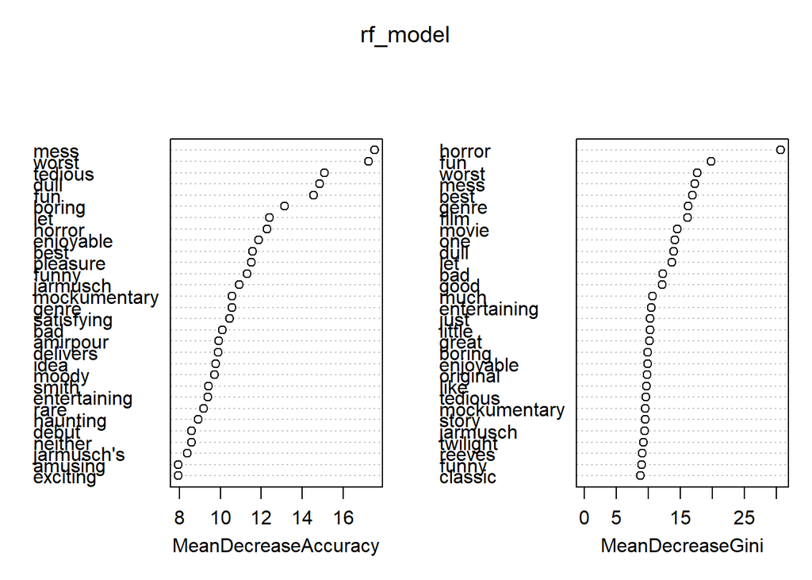

```r
# compare feature importances
varImpPlot(rf_model)
```

According to the variable importance plot, some of the most important features that we can assume to be negative are: “mess,” “worst,” “tedious,” “dull,” and “boring.” Some of the most important features that we can assume to be positive are: “fun,” “enjoyable,” “best,” “pleasure,” and “entertaining.”

### Topic Modeling

In addition to building ML models, I wanted to see which topics could be extracted from the reviews.

```r
# add new column to dataframe with sentiment as binary numeric variable
vamp_reviews <- vamp_reviews |>
  mutate(review_freshness01 = ifelse(review_freshness=="Fresh", 1, 0))

# create DFM using all reviews and all features
dfmAll <- tokens(vamp_reviews$review_content, remove_punct = TRUE, remove_numbers = TRUE) |>
  dfm() |> dfm_remove(stopwords('english'))
dim(dfmAll)
```

```
[1]  8254 16264
```

```r
# build structural topic model with 5 topics
vamp_stm <- stm(dfmAll, K = 5, data = vamp_reviews,
               prevalence = ~ review_freshness01,
               max.em.its = 500, seed = 12,
               init.type = "Spectral", verbose = FALSE)
```

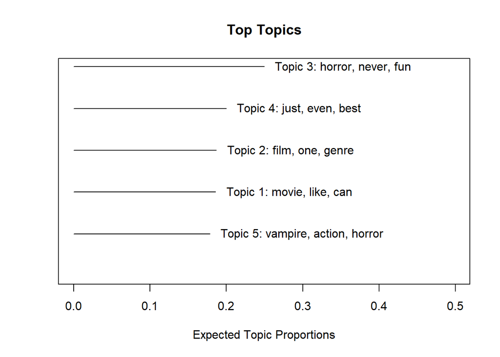

```r
# visualize the 5 topics
plot(vamp_stm, type="summary")
```

```r
# examine top words that define each topic
labelTopics(vamp_stm)
```

```
Topic 1 Top Words:
     Highest Prob: movie, like, can, movies, make, something, twilight
     FREX: something, make, feels, can, nothing, sense, movies
     Lift: grains, sand, over-designed, carroll, freud, lewis, marquis
     Score: movie, can, movies, make, something, like, feels
Topic 2 Top Words:
     Highest Prob: film, one, genre, much, plot, blood, good
     FREX: one, film, anything, far, say, genre, plot
     Lift: entwined, fates, smeared, soften, victim's, another's, whelmed
     Score: film, one, genre, much, plot, far, director
Topic 3 Top Words:
     Highest Prob: horror, never, fun, like, full, series, enough
     FREX: never, books, beauty, helsing, van, full, spanish
     Lift: bamboo, dashes, drawl, edo-era, fetishists, punchy, rubbery
     Score: never, fun, horror, effects, like, full, series
Topic 4 Top Words:
     Highest Prob: just, even, best, time, might, characters, dracula
     FREX: might, best, just, takes, piece, back, lost
     Lift: accountably, energetically, family-movie, ickiness, magnum, sky, unflinching
     Score: just, best, even, might, time, back, takes
Topic 5 Top Words:
     Highest Prob: vampire, action, horror, original, much, story, flick
     FREX: vampire, action, likely, abraham, black, hunter, lincoln
     Lift: adventuress, blond, fixations, locks, nancy, pitch, roll's
     Score: vampire, action, original, much, horror, let, hunter
```

```r
# name topics using top 3 words in "score" category from each topic
topicNames <- labelTopics(vamp_stm, n=3)$score
topicLabels <- rep(NA, 5)
for (i in 1:5){
  topicLabels[i] <- paste(topicNames[i,], collapse = "_")
}
topicLabels
```

```
[1] "movie_can_movies"        "film_one_genre"
[3] "never_fun_horror"        "just_best_even"
[5] "vampire_action_original"
```

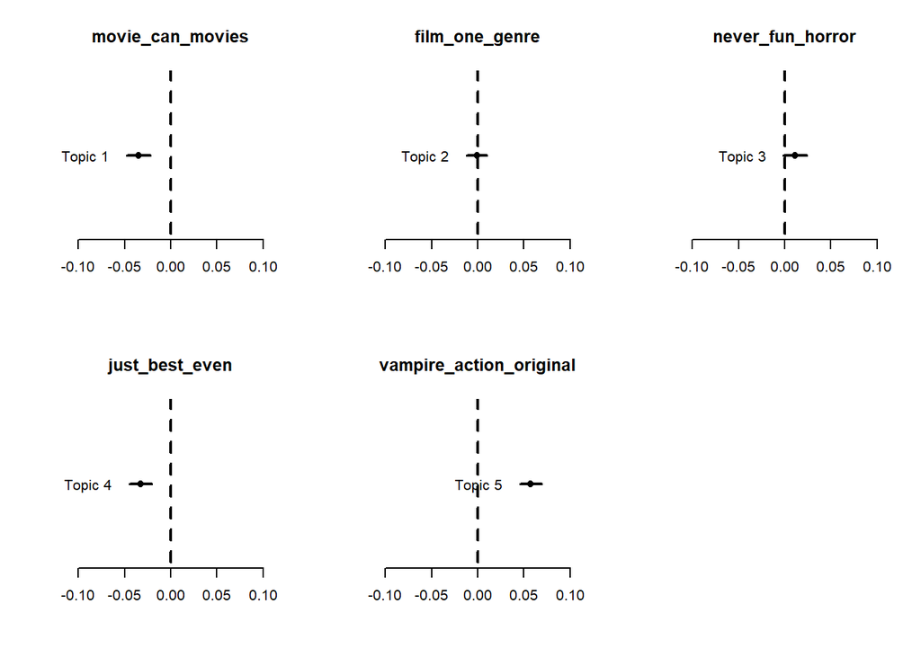

```r
# estimate and plot effects of review freshness on topics
modelEffects <- estimateEffect(formula = 1:5 ~ review_freshness01,
                               stmobj = vamp_stm,
                               metadata = vamp_reviews)
par(mfrow = c(2, 3), bty = "n", lwd = 2)
for (i in 1:5){
  plot.estimateEffect(modelEffects,
                      covariate = "review_freshness01",
                      xlim = c(-.1, .1),
                      model = vamp_stm,
                      topics = modelEffects$topics[i],
                      method = "difference",
                      cov.value1 = 1,
                      cov.value2 = 0,
                      main = topicLabels[i],
                      printlegend = F,
                      verbose.labels = F)
  par(new = F)
}
```

### Conclusions

Out of the three supervised learning models that I applied to my data, the Naive Bayes model performed the best, with a classification accuracy of 70%. The Random Forest and Support Vector Machine models were close behind, with accuracies of 68% and 67%, respectively. Since all of these results were obtained using only one training and testing set of data, I need to rerun all of these models on different random subsets of the data to see whether I get similar results. I could also develop an ensemble model, giving equal weight to the Naive Bayes, Random Forest, and SVM models, since they all performed relatively equally, to see if those predictions would be at all improved over those from the individual models.

Throughout my analysis, I have repeatedly come across the issue of the high weight that is given to words about specific vampire movies that are almost exclusively positively or negatively reviewed. For example, words that are associated with *A Girl Walks Home Alone at Night*, directed by Ana Lily Amirpour (including “Iranian” and “Amirpour”), *Only Lovers Left Alive*, directed by Jim Jarmusch (including “Jarmusch” and “Jarmusch’s”), and *What We Do in the Shadows*, directed by Taika Waititi and Jemaine Clement (including “shadows” and “mockumentary”), are repeatedly featured in the positive word analyses. Likewise, words that are associated with the *Twilight*, *Underworld*, and *Blade* series are repeatedly featured in the negative word analyses. I considered removing references to specific movie titles, characters, or creative personnel from my corpora, but that may have led to a loss of information in reviews that refer to these other movies in a positive or negative comparative way.

Overall, I saw evidence to support both of my initial hypotheses. Fresh reviews of vampire movies frequently included words such as “good,” “great,” “best,” “fun,” “original,” “love,” “entertaining,” “classic,” and “pleasure.” Rotten reviews of vampire movies frequently included words such as “bad,” “dull,” “poor,” “boring,” “worst,” “nothing,” “mess,” “tedious,” and “flat.” These results align with what I expected to see from my first hypothesis. Additionally, the word “horror” was repeatedly associated more with Fresh reviews than Rotten reviews, which aligns with my second hypothesis.

In the future, I would like to apply my supervised learning models to reviews of newer vampire movies on Rotten Tomatoes that were published after 2020 and thus weren’t included in my dataset. I would be curious to see how well the models would perform on this new data to determine whether the results I’ve observed so far could be considered generalizable or not.